# Introduction to Data Science - 21MAP500 - Coursework

Last Updated: Oct 21, 2021

```r
data_paths <- list.files(path=here("data"), full.names=TRUE)
# Store path to 'data' folder in a list to easily access data files
options(scipen=8)
# Fixed notation will be preferred unless it is more than 8 digits wider
```

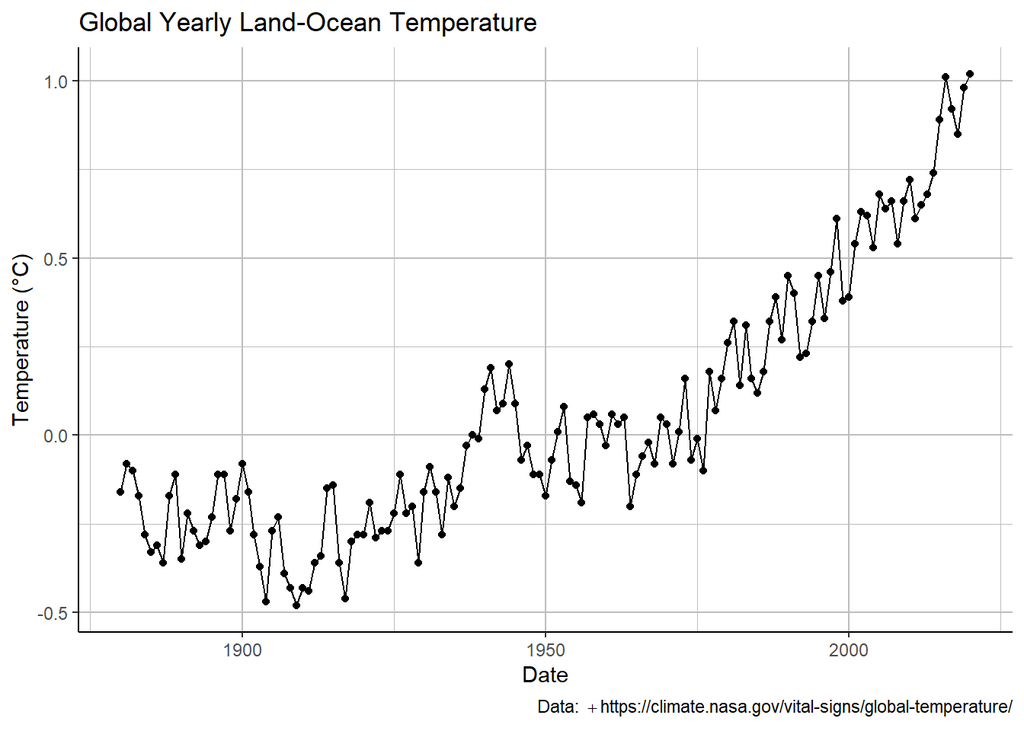

```r
nasa_temp_col_names <- c("date", "temp", "X3")
# Character vector to define column names in order
nasa_temp_col_types <- list("date"=col_date(format="%Y"),
                            # "format" argument enforces YYYY-01-01 format
                            "temp"=col_double(),
                            # Set numerical type "double"
                            "X3"=col_skip())
                            # Skip adding this column to the tibble
# List mapping column names to types contained in that column
nasa_temp <- read_table(file=data_paths[4],
                        # 4th element in path list
                        col_names=nasa_temp_col_names,
                        # Column names as defined in "nasa_temp_col_names"
                        col_types=nasa_temp_col_types,
                        # Column types as defined in "nasa_temp_col_types"
                        skip=5)
                        # Skip first 5 rows as they contain no data
# Store data in 'nasa_temp' tibble using read_table as the data isn't comma-separated
ggplot(data=nasa_temp, aes(x=date, y=temp))+
  # Plot "nasa_temp" tibble and map columns to axis
  geom_line()+
  # Specify plot type (line plot) and leave the line as the default colour (black)
  geom_point(color="black")+
  # Mark each data point with a black dot on the plot
  labs(title="Global Yearly Land-Ocean Temperature",
       # Set plot title to specified string
       x="Date",
       # Set X-axis label to specified string
       y="Temperature (\u00B0C)",
       # Set Y-axis label to specified string. \u00B0 is the unicode value for degree symbol
       caption=expression(
         "Data: " +
         "https://climate.nasa.gov/vital-signs/global-temperature/"))+
       # Use expression to break down long string and set caption to specified string (link to data source)
  theme(panel.grid = element_line(color="grey"),
        # Add grey coloured major and minor grids
        axis.line = element_line(),
        # Insert axis lines with default parameters (black, size 1)
        panel.background = element_blank())
```

```r
        # Remove background panel
  # Change default label values such as title, x-axis and y-axis labels
```

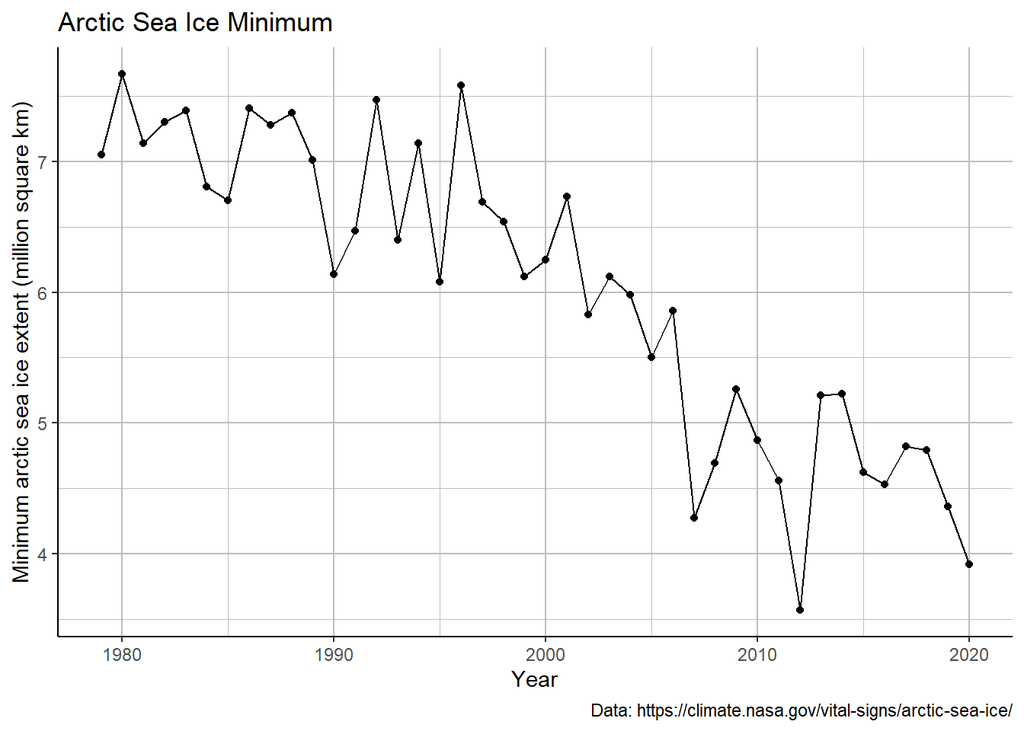

```r
nasa_ice_col_names = c("date", "X2", "X3", "X4", "ice", "X6")
# Assign relevant labels only to desired columns
nasa_ice_col_types = list("date"=col_date(format = "%Y"),
                          "X2"=col_skip(),
                          "X3"=col_skip(),
                          "X4"=col_skip(),
                          "ice"=col_double(),
                          "X6"=col_skip())
# Assign data types to desired columns. Assign "skip" to columns to be dropped
nasa_ice <- read_csv2(file=data_paths[2],
                     col_names=nasa_ice_col_names,
                     col_types=nasa_ice_col_types,
                     skip=1)
                     # Skip header line to assign desired column names rather than those provided
# Use read_csv2 as this data set follows European convention (i.e. ";" to separate values, "," to separate decimals)
ggplot(data=nasa_ice, aes(x=date, y=ice)) +
  geom_line()+
  geom_point(color="black")+
  labs(title="Arctic Sea Ice Minimum",
       x="Year",
       y="Minimum arctic sea ice extent (million square km)",
       caption="Data: https://climate.nasa.gov/vital-signs/arctic-sea-ice/")+
  theme(panel.grid = element_line(color="grey"),
        axis.line = element_line(),
        panel.background = element_blank())
```

```r
# Same as Q1a, plot a line chart with the same parameters but a different data set
```

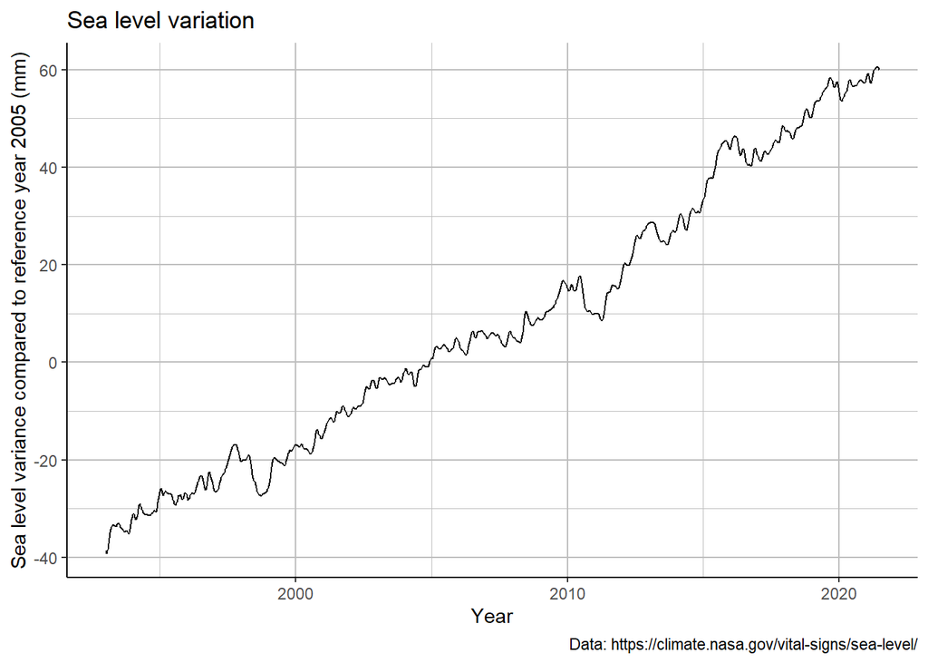

```r
nasa_sea_col_names = c(
  "X1", "X2", "date", "X4", "X5", "X6", "X7", "X8", "X9", "X10", "X11", "sea")
# Assign names to columns
nasa_sea_col_types = list(
  "X1"=col_skip(),
  "X2"=col_skip(),
  "date"=col_double(),
  "X4"=col_skip(),
  "X5"=col_skip(),
  "X6"=col_skip(),
  "X7"=col_skip(),
  "X8"=col_skip(),
  "X9"=col_skip(),
  "X10"=col_skip(),
  "X11"=col_skip(),
  "sea"=col_double())
# Assign data types to columns according to their names
nasa_sea <- read_table(file=data_paths[5],
                     col_names=nasa_sea_col_names,
                     col_types=nasa_sea_col_types,
                     skip=48) %>%
  # Read data set using read_table as values aren't delimited by a separator
  mutate(date=date_decimal(date, tz="UTC")) %>%
  # Convert decimal to UTC time zone datetime
  mutate(date=as_date(date))
  # Set "date" type as date instead of datetime
ggplot(data=nasa_sea, aes(x=date, y=sea))+
  geom_line()+
  labs(title="Sea level variation",
       x="Year",
       y="Sea level variance compared to reference year 2005 (mm)",
       caption="Data: https://climate.nasa.gov/vital-signs/sea-level/")+
  theme(panel.grid = element_line(color="grey"),
        axis.line = element_line(),
        panel.background = element_blank())
```

```r
# Same as Q1a and Q1b, plot a line chart. No dots for data points due to visualisation impairment
```

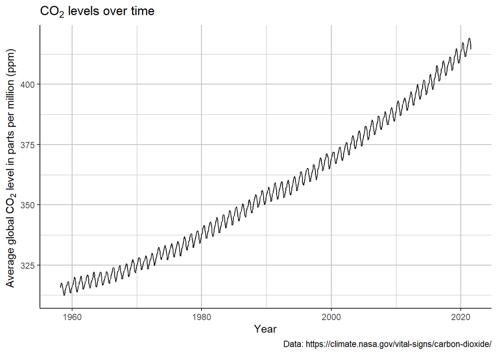

```r
nasa_co2_col_names = c("X1", "X2", "date", "co2", "X5", "X6", "X7", "X8")
# Assign names to columns
nasa_co2_col_types=list(
  "X1"=col_skip(),
  "X2"=col_skip(),
  "date"=col_double(),
  "co2"=col_double(),
  "X5"=col_skip(),
  "X6"=col_skip(),
  "X7"=col_skip(),
  "X8"=col_skip())
# Assign data types to columns according to their names
nasa_co2 <- read_table(file=data_paths[3],
                       col_names=nasa_co2_col_names,
                       col_types=nasa_co2_col_types,
                       comment="#") %>%
                       # Define line starting with "#" as comments in the data file
  mutate(date=date_decimal(date)) %>%
  # Convert date from decimal type to datetime type
  mutate(date=as.Date(date, format= "%Y-%m-%d")) %>%
  # Set "date" type as date instead of datetime
  mutate(date=floor_date(date, unit="month")) %>%
    # Round down to nearest month according to specification
    filter(co2>0)
    # Filter out "co2" values below "0" as these are impossible, so the recorded data must be wrong
  ggplot(data=nasa_co2, aes(x=date, y=co2))+
    geom_line()+
    labs(title=expression("CO"[2]*" levels over time"),
         # Calling the "expression()" method to enable the use of subscript for "CO2" string
         x="Year",
         y=expression("Average global CO"[2]*" level in parts per million (ppm)"),
         caption="Data: https://climate.nasa.gov/vital-signs/carbon-dioxide/")+
         # Calling the "expression()" method to enable the use of subscript for "CO2" string
    theme(panel.grid = element_line(color="grey"),
          axis.line = element_line(),
          panel.background = element_blank())
```

```r
  # Same as previous questions, plot a line chart
```

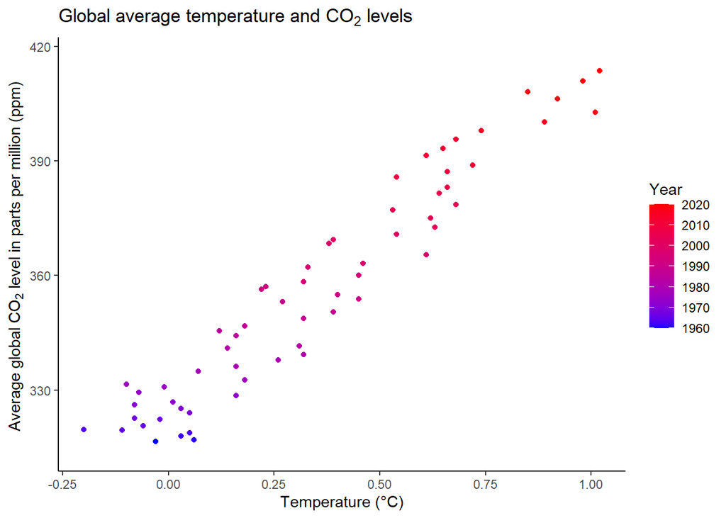

```r
ggplot(data=nasa %>%
         filter(date >= as.Date("1960-01-01") & date < as_date("2021-01-01")),
         # Filter out dates outside of the 1960-2021 range before plotting
       aes(x=temp, y=co2))+
       # Map out values to plot after filtering
  geom_point(aes(color=year(date)))+
  # Sequential colouring of data points according to their values, defining a scale based on the value range
  scale_color_gradient(low="blue", high="red")+
  # Select non-default colours for better visualisation (i.e blue is low, red is high)
  labs(title=expression("Global average temperature and CO"[2]*" levels"),
       x="Temperature (\u00B0C)",
       y=expression("Average global CO"[2]*" level in parts per million (ppm)"),
       color="Year")+
  theme(axis.line = element_line(),
        panel.background = element_blank())
```

```r
       # Map the legend colour to "Year" value
# Use default ggplot plot type (scatter) - this happens by not calling "geom_line()" method within the "ggplot" function
```

```r
historic_co2_col_names = c("yrbp", "co2")
# Assign names to columns
historic_co2_col_types = list("yrbp" = col_integer(),
                              "co2" = col_double())
# Assign data types to columns according to their names
historic_co2 <- read_table(file=data_paths[1],
                           col_names = historic_co2_col_names,
                           col_types = historic_co2_col_types,
                           skip=774)
# Read the data file into the "historic_co2" tibble and skip the first 774 lines as they don't contain relevant data
```

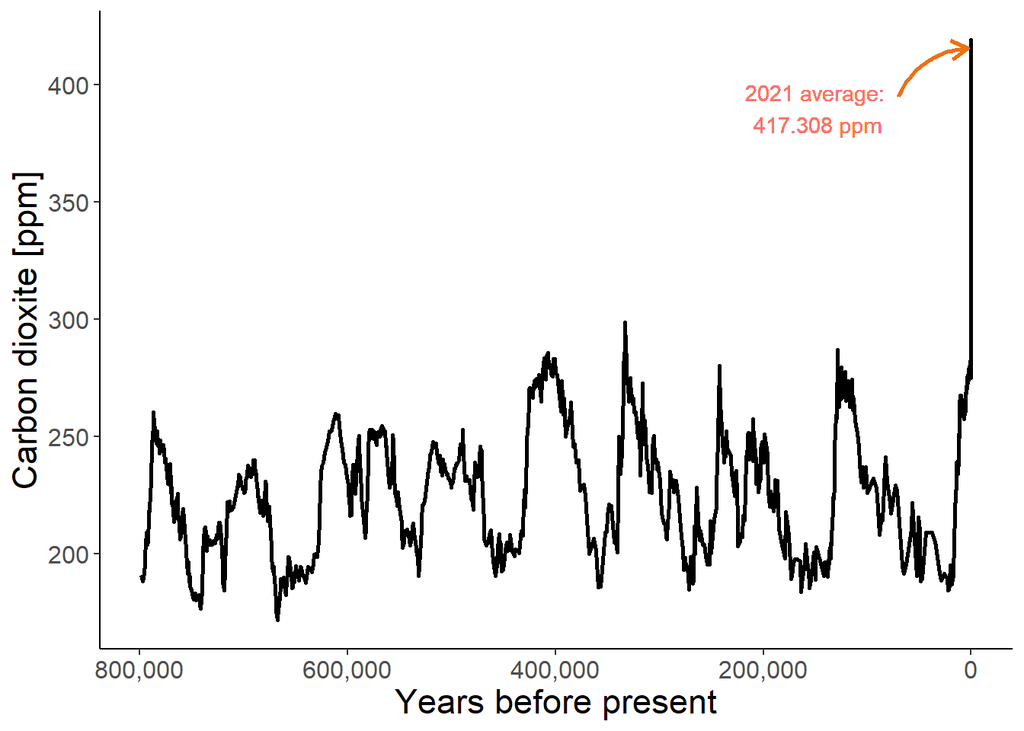

```r
avg <- filter(combined_co2, yrbp == 0) %>%
  # Filter only "yrbp" == 0, i.e. year 2021 to calculate average
  colMeans(co2) %>%
  # Calculate column "co2"'s average
  unname()
  # Remove name of variable to only be left with 1 cell for ease of displaying on plot
# Calculate "avg" variable to display on plot
ggplot(data=combined_co2, aes(x=yrbp, y=co2))+
  geom_line(color="black", size = 0.9)+
  # Line plot, set size, i.e. line thickness to 0.9 for a closer match
  scale_x_reverse(labels = comma)+
  # Reverse x-axis scale (right to left) and delimit thousands by commas
  labs(x="Years before present", y="Carbon dioxite [ppm]")+
  # Specify axis label names
  theme_classic()+
  # Use theme_classic() settings to skip additional steps
  geom_curve(aes(x=70000, y=395, xend = 3000, yend = 415.52),
    arrow = arrow(length = unit(0.03, "npc"),
                  type="open"),
    # Specify that the curve is an arrow and define some parameters
    colour = "#EC7014",
    # Set hexadecimal orange shade colour for a closer match (closer than orange)
    size = 0.9,
    # Set thickness of arrow curve
    angle = 90,
    # Set the angle of the arrow
    curvature = -0.3)+
    # Negative curvature enforces a 'mirrored' arrow curve
  # Plot a new "curve" (the arrow)
  geom_text(aes(x = 150000, y = 390,
                label = sprintf("2021 average:\n %g ppm", avg[2]),
                # "%g" is a numerical placeholder, specifying that a numerical variable is expected after the string
                color="#EC7014"))+
  # Manually define the position of the text next to the arrow
  theme(legend.position = "none",
        # Remove legend from plot
        axis.title = element_text(size = 17),
        axis.text = element_text(size = 12))
```

```r
        # Resize the plot's title and axis labels' fonts for a closer match
  # Override some of "theme_classic()" settings
```

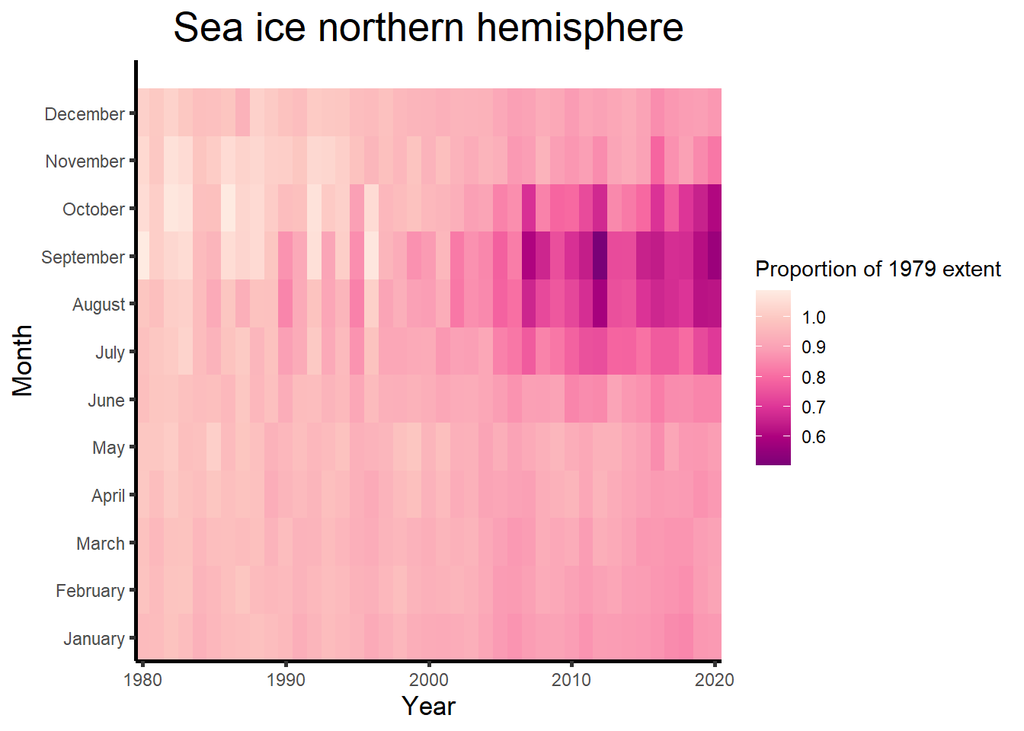

```r
sea_ice_2 %>% filter(year > 1979 & year < 2021) %>%
  # Select only years in the range 1979 to 2021 for plotting
  ggplot()+
  geom_tile(aes(x=year, y=month.name[month],
                fill = proportion_baseline_extent))+
  # Specify plot type as tile (i.e. heat map) and map out values to axis and heat map fill data
  scale_fill_distiller(palette="RdPu", name = "Proportion of 1979 extent")+
  # Specify the colour palette to be used to fill the heatmap and redefine legend name
  scale_y_discrete(limits = month.name, expand = expansion(mult =c(0, 0.1)))+
  # Sort Y-axis label in ascending order (January to December) rather than the default (alphabetical)
  scale_x_continuous(expand = c(0, 0))+
  # Set the X-axis scale type as continuous (non-discrete values) and remove gap between axis and tiles
  labs(title="Sea ice northern hemisphere",
       x="Year",
       y="Month")+
  # Change plot label names
  theme(axis.title = element_text(size = 13),
        plot.title = element_text(size = 20,
                                  hjust = 0.5),
        axis.line = element_line(size = 1),
        axis.ticks = element_line(size = 1),
        panel.background = element_blank())
```

```r
  # Override some of theme_classic()'s settings for a closer matching plot
# Plot a heat map
```

```r
stop_search_col_names = c("X1", "year", "X3", "ethnicity", "X5",
                          "legislation_type", "geography", "X8",
                          "stops", "X10", "population","rate",
                          "X13", "X14")
# Assign names to columns
stop_search_col_types = list(
  "X1" = col_skip(),
  "year" = col_character(),
  # Assign data type "character" to "year" column due to unusual format (i.e. "2006/07") as this cannot be parsed as a typical numerical value
  "X3" = col_skip(),
  "ethnicity" = col_character(),
  "X5" = col_skip(),
  "legislation_type" = col_character(),
  "geography" = col_character(),
  "X8" = col_skip(),
  "stops" = col_character(),
  # Temporarily define as "character" type due to data set containing only some (not all) values which use commas for separating thousands
  "X10" = col_skip(),
  "population" = col_character(),
  # Temporarily define as "character" type due to data set containing only some (not all) values which use commas for separating thousands
  "rate" = col_double(),
  "X13" = col_skip(),
  "X14" = col_skip())
# Assign data types to columns according to their names
stop_search_1 <- read_csv(file=data_paths[7],
                          col_types=stop_search_col_types,
                          col_names=stop_search_col_names,
                          skip=1) %>%
  # Skip the first row as it contains column headers but this tibble will use custom column names
  filter(ethnicity == "All" |
         ethnicity == "Asian" |
         ethnicity == "Black" |
         ethnicity == "White" |
         ethnicity == "Other") %>%
  # Filter out data where "ethnicity" is not one of "All", "Asian", "Black", "White", or "Other"
  mutate(stops = as.integer(gsub(",", "", stops))) %>%
  # Remove comma thousand separators from the "stops" column and change column's type to "integer"
  mutate(population = as.integer(gsub(",", "", population)))
  # Remove comma thousand separators from the "population" column and change column's type to "integer"
```

```r
rate_white <- select(stop_search_1, c(1, 3, 4 ,7)) %>%
  # Select columns at positions 1, 3, 4 and 7 from the "stop_search_1" tibble
  filter(stop_search_1$ethnicity == "White") %>%
  # Filter out any observations where "ethnicity" variable is not "White"
  mutate(rate_white = rate)
  # Rename column "rate" to "rate_white" for clarity
# Create a new tibble containing the stop-and-search rate for the "White" ethnicity and other variable used for identification
stop_search_2 <- stop_search_1 %>%
  left_join(rate_white, by = c("year", "legislation_type", "geography")) %>%
  # Return all rows from stop_search_1, and any rows with matching "year", "legislation_type" and "geography" from the "rate_white" tibble
  select(-9) %>%
  # Drop redundant "rate_white" column
  rename(rate_white = rate.y) %>%
  # Rename "rate.y" to "rate_white"
  rename(rate = rate.x) %>%
  # Rename "rate.x" to "rate"
  distinct() %>%
  # Remove duplicate rows (where all variables match)
  mutate(relative_disparity = rate / rate_white)
  # Create a new column and store the result of the rate / rate_white calculation
```

1. Has the relative disparity of stop-and-search rates for people of Asian and Black ethnicity increased or decreased over the years?

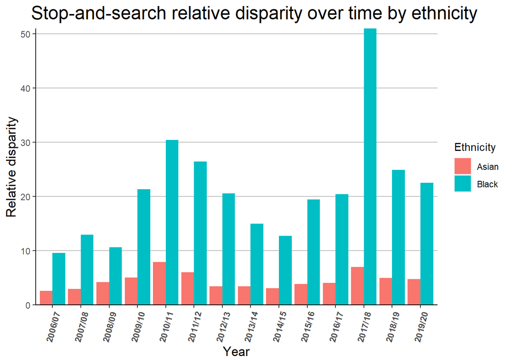

```r
stop_search_2 %>%
  filter(ethnicity != "Other" & ethnicity != "All" & ethnicity != "White") %>%
  # Filter out any ethnicity groups belonging to "Other", "All" and "White"
  ggplot(aes(fill=ethnicity, x=year, y=relative_disparity))+
    geom_col(position = "dodge")+
    # Plot a grouped bar chart ("dodge" to unstack the bars)
    labs(title="Stop-and-search relative disparity over time by ethnicity",
         x="Year",
         y="Relative disparity",
         fill="Ethnicity")+
    # Change title, axis labels and legend label
    scale_y_continuous(expand = c(0,0),
                       # Remove gap between x-axis and bars
                       minor_breaks = seq(0, 100, 10))+
                       # Insert horizontal grid lines between y-values 0-100 in increments of 10
    # Set y-axis as continuous
    theme(axis.title = element_text(size = 13),
          # Resize axis titles
          axis.text.x = element_text(angle=75, vjust = 0.5, face = "bold"),
          # Change angle of x-axis tick labels to 75 deg, move downwards and make font bold
          plot.title = element_text(size = 18, hjust = 0.1),
          # Resize title and move to the right
          panel.grid.major.y = element_line(color = "grey"),
          # Set colour of horizontal grid lines to grey
          panel.grid.major.x = element_blank(),
          # Remove vertical grid lines
          panel.background = element_blank(),
          # Remove background panel
          axis.line = element_line(colour = "black"))
```

```r
          # Set axis lines colour as black
    # Change theme settings
  # Plot bar chart
```

Between 2006 and 2020, the relative disparity has increased for both ethnic groups, meaning that there is a larger stop-and-search rate for people belonging to these categories in proportion to people belonging to the White ethnic group than in the past. As observed on the bar plote above, this trend peaked in 2017/18 for the Black ethnic category, and in 2010/11 for the Asian ethnic category.

2. In what geographical area of UK do the most stop-and-searches occur?

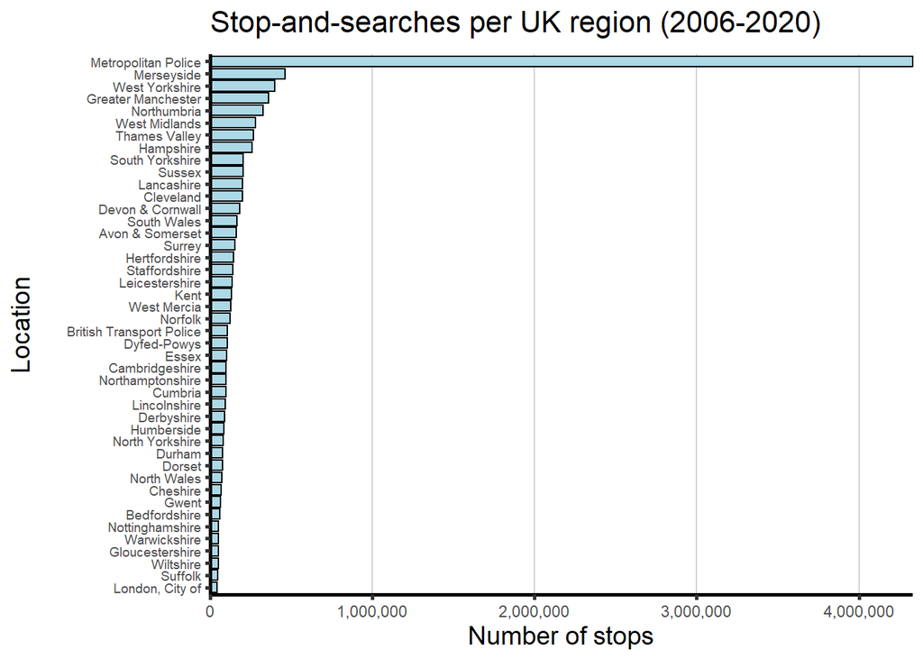

```r
stop_search_2 %>%
  filter(geography != "All - excluding BTP" &
         geography != "All - excluding BTP and Greater Manchester" &
         geography != "All - including BTP and excluding Greater Manchester" &
         geography != "All - including BTP") %>%
  # Filter out non-individual geography groups
  filter(ethnicity != "All") %>%
  # Filter out ethnicity group "All"
  drop_na(stops) %>%
  # Remove rows where "stops" value is NA
  group_by(geography) %>%
  summarise(stops = sum(stops)) %>%
  # Reduce the number of rows by summing the amount of stops per geographic group
  ggplot(aes(x=reorder(geography, stops), y=stops))+
  # Plot bars by geography in order of stops
  geom_bar(width = 0.85, stat = "identity", fill = "lightblue", color = "black")+
  # Define bars' parameters on bar plot
  scale_y_continuous(label=comma, expand = c(0, 0))+
  # Add comma thousand separators on y-axis labels and remove gap between axis and bars
  scale_x_discrete()+
  # Set x-axis as discrete
  labs(title=expression("Stop-and-searches per UK region (2006-2020)"),
       x="Location\n",
       # Newline character to create a gap between axis label and axis tick labels
       y="Number of stops")+
  theme(axis.title = element_text(size = 14),
        plot.title = element_text(size = 16),
        axis.line = element_line(size = 1),
        axis.text.y = element_text(size = 7),
        axis.ticks = element_line(size = 1),
        panel.background = element_blank(),
        panel.grid.major.x = element_line(color="lightgrey"))+
  # Resize title, axis labels, axis tick labels, axis ticks, remove panel background and customize grid
  coord_flip()
```

```r
  # Flip x and y-axis
```

Clearly, the area governed by the Metropolitan Police (i.e. Greater London region, excluding the City of London) is where most stop-and-searches occur in UK. This may be attributed to a higher population concentration, however, further analysis is required to establish that.

3. Are any of the ethnic categories related to stop-and-searches under one legal article section?

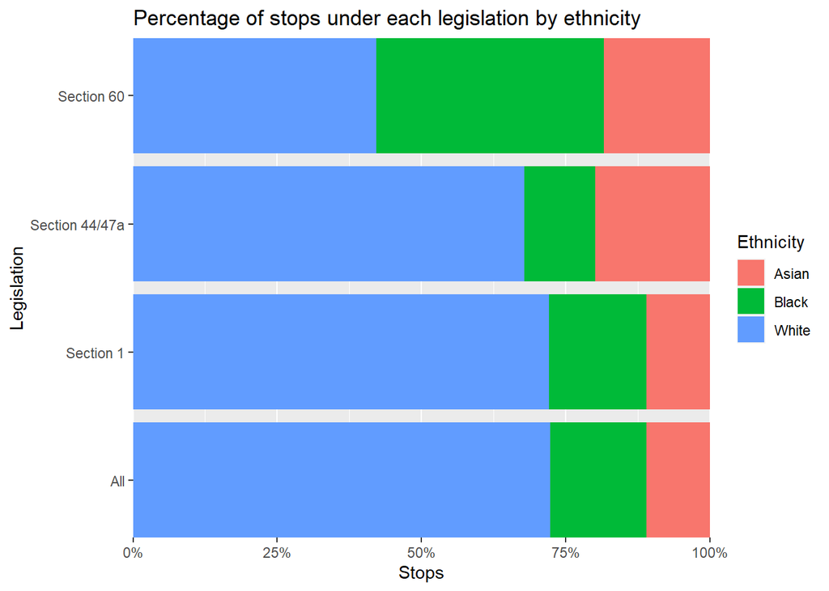

```r
stop_search_2 %>% filter(ethnicity != "All" & ethnicity != "Other") %>%
  # Filter out "All" and "Other" ethnicity groups
  ggplot(aes(x=legislation_type, y=stops, fill=ethnicity))+
  # Map values to plot
  geom_bar(position="fill", stat="identity")+
  # "fill" to stack bars
  scale_y_continuous(labels=percent_format(), expand = c(0,0))+
  # Change y-axis scale to continuous to enable percentage format. Also remove gap between axis and bars
  scale_x_discrete(expand = c(0,0))+
  # Set x-axis as discrete and remove gap between bars and axis
  coord_flip()+
  # Flip x and y-axis
  labs(title = "Percentage of stops under each legislation by ethnicity",
       x = "Legislation",
       y = "Stops",
       fill = "Ethnicity")
```

```r
  # Change label text
```

Overall, people of Asian ethnicity seem to be mostly affected by Section 44/47a, with people of Black ethnicity being most affected by Section 60 and people of White ethnicity being affect by All legislation types on average. However, it is worth noting that this data does not cover equally-sized samples of each ethnic category.